# Тестирование статистических гипотез

## Тестирование гипотез

- Выборочное распределение среднего значения
- Как устроено тестирование гипотез
- t-статистика
- Применение t-теста
- Статистическая значимость

## Выборочная оценка среднего

## Как можно судить о свойствах генеральной совокупности по выборке?

**Центральная предельная теорема** (ЦПТ) говорит, что если мы возьмем достаточно большую выборку из генеральной совокупности, то среднее значение будет нормально распределено с параметрами \(\mu_{\bar x}\) и \(\sigma _{\bar{x}}\):

\[\bar X \sim N (\mu_{\bar x}, \sigma_{\bar x})\]

При чем \(\sigma_{\bar x} = \sigma/\sqrt{n}\).

Но самое важное, что при больших объемах выборки (\(N > 30\), или даже \(N > 100\)) это так, даже если \(x\) в генеральной совокупности не подчиняется нормальному распределению.

Давайте проверим на опыте, так ли это.

## Цена алмазов

Представим, что данные об алмазах из датасета `diamonds` (пакет `gplot2`) — это генеральная совокупность.

Перед вами распределение цены алмазов. Давайте будем брать из этого распределения выборки и оценивать по ним среднее значение.

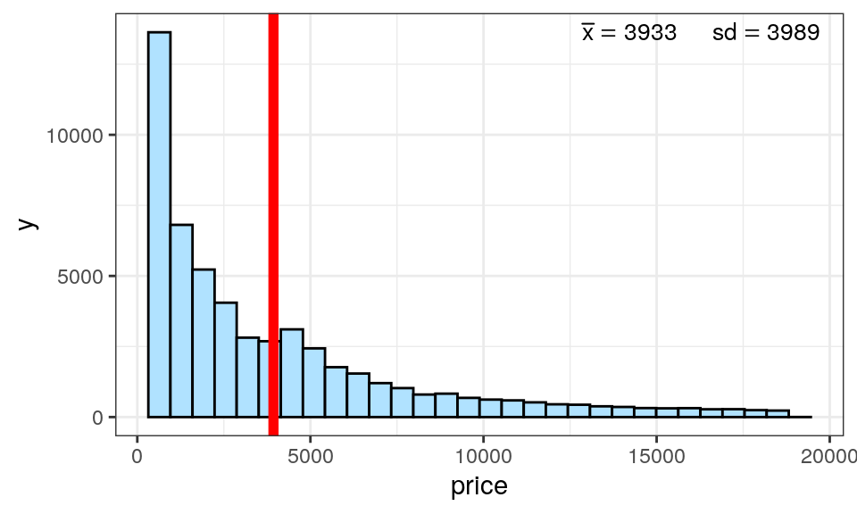

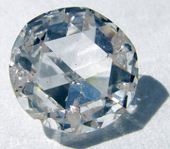

Diamond Age by Steve Jurvetson on Flickr

## Средние в выборках

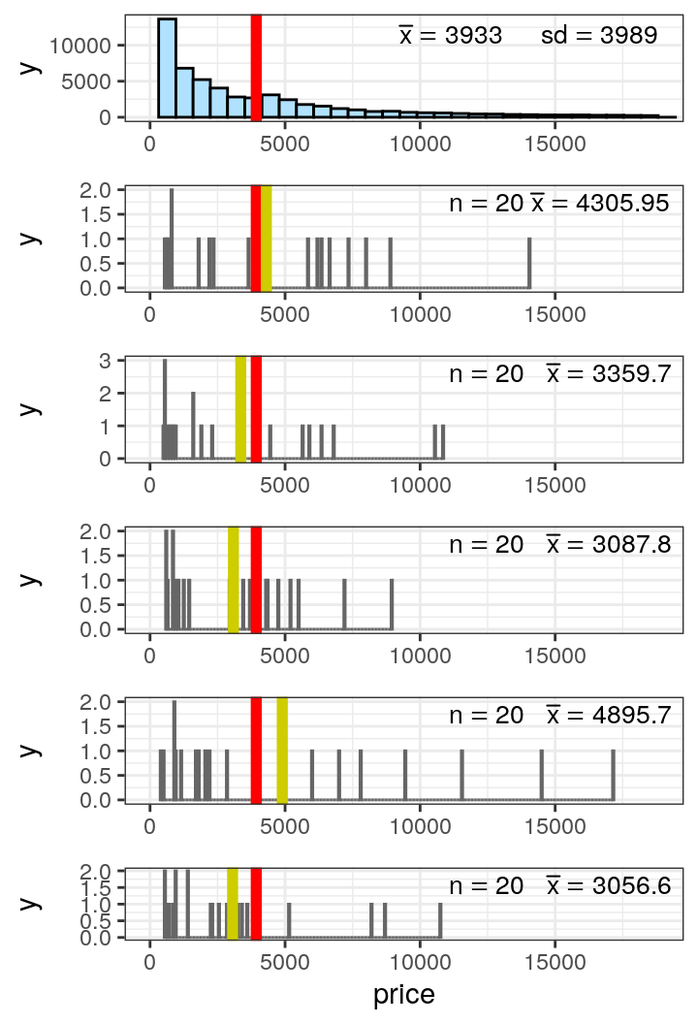

Средние в выборках отличаются от среднего в генеральной совокупности.

Если взять много выборок определенного размера, можно построить распределение выборочных средних.

Давайте посмотрим, как меняется форма распределения выборочных средних при изменении объема выборки.

## Распределение выборочных средних

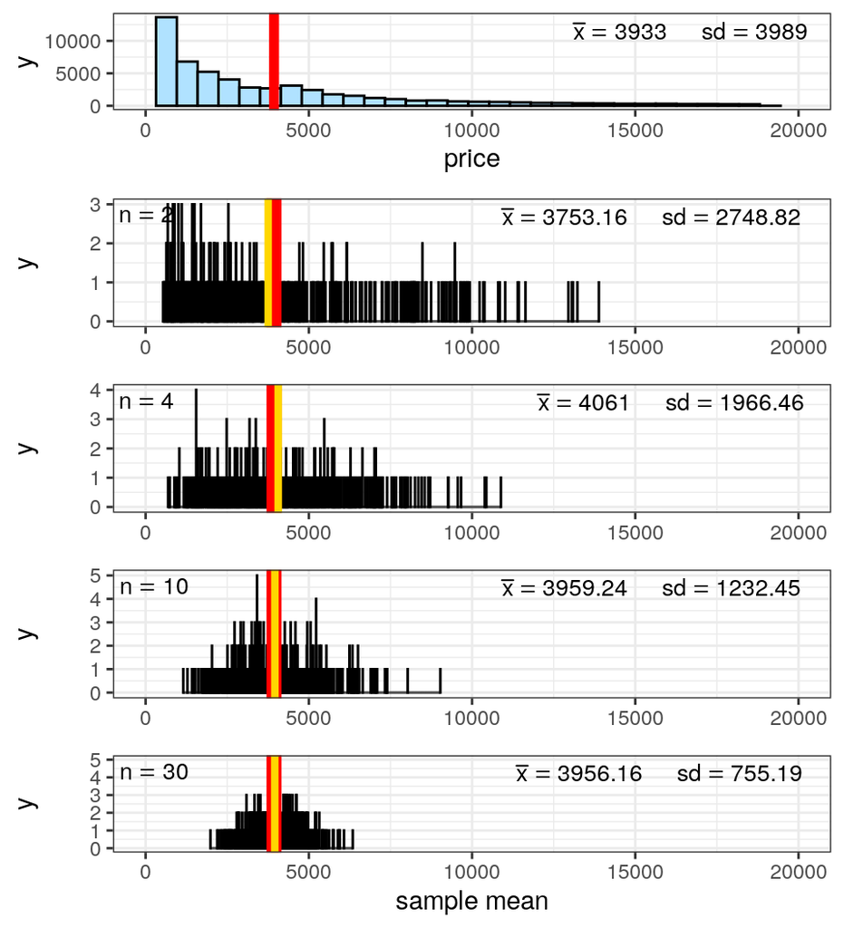

\[\bar X \sim N (\mu_{\bar x}, \sigma_{\bar x})\]

\(\mu_{\bar x} = \mu\) — среднее значение выборочных средних стремится к среднему в генеральной совокупности.

\(\sigma_{\bar x} = \sigma / \sqrt{n}\) — стандартное отклонение в \(\sqrt{n}\) раз меньше стандартного отклонения в генеральной совокупности.

\(\sigma_{\bar x}\) называют стандартной ошибкой среднего и обозначают \(SE _{\bar{x}}\).

## Центральная предельная теорема очень важна в статистике

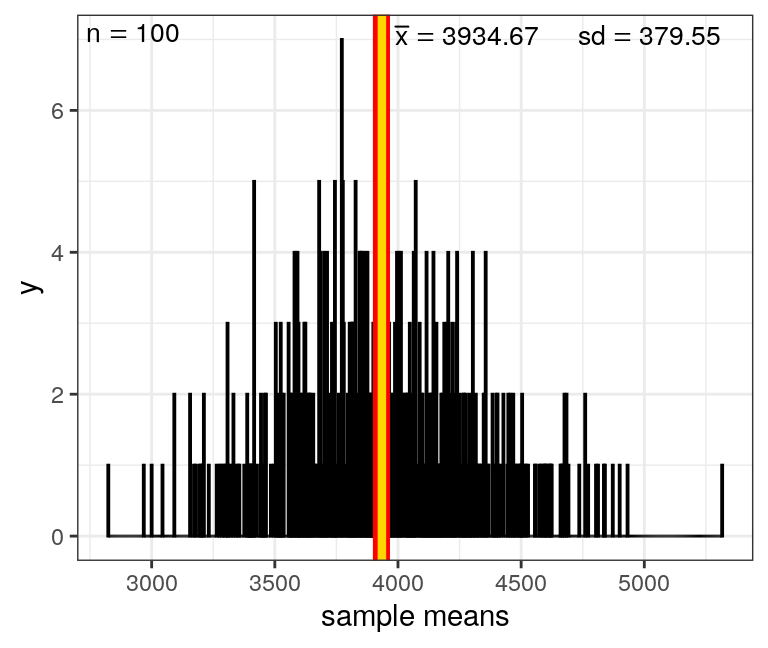

\[\bar X \sim N (\mu, \sigma / \sqrt{n})\]

Пользуясь ее выводами, мы сможем:

- строить доверительные интервалы
- тестировать гипотезы

## Доверительный интервал

## Если выполняется центральная предельная теорема, то

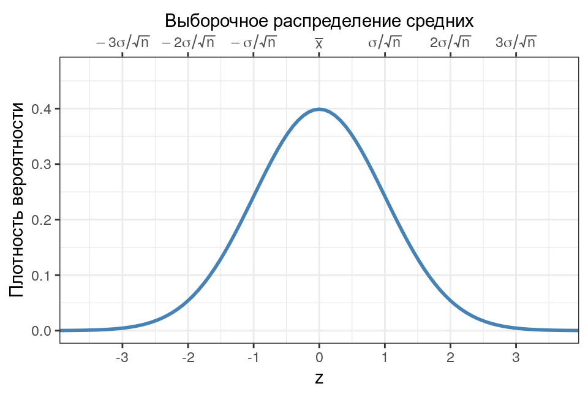

\[\bar X \sim N(\mu, \sigma/ \sqrt{n})\]

После стандартизации:

\[\frac{\bar X - \mu}{\sigma / \sqrt{n}} \sim N(0, 1)\]

Стандартизованное распределение выборочных средних будет подчинятся стандартному нормальному распределению.

## Доверительный интервал из нормального распределения

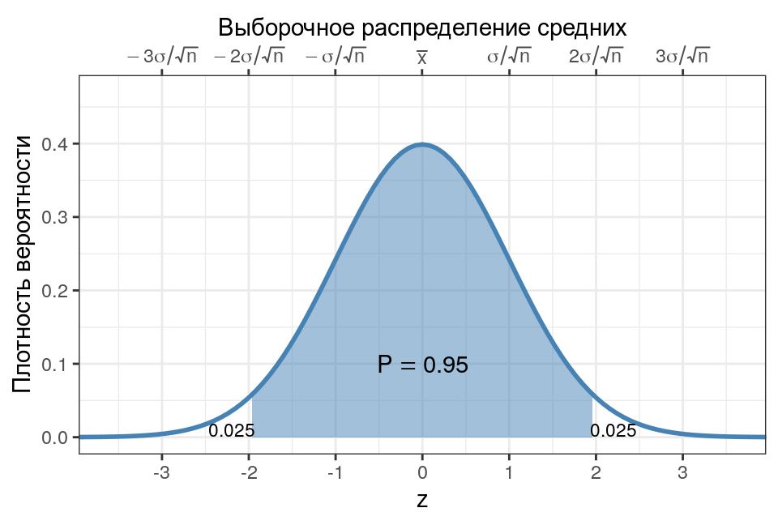

— это интервал, в который попадает заданный процент выборочных средних.

В 95% доверительный интервал попадает выборочное среднее в 95% повторных выборок.

Как найти этот интервал?

## Доверительный интервал из нормального распределения

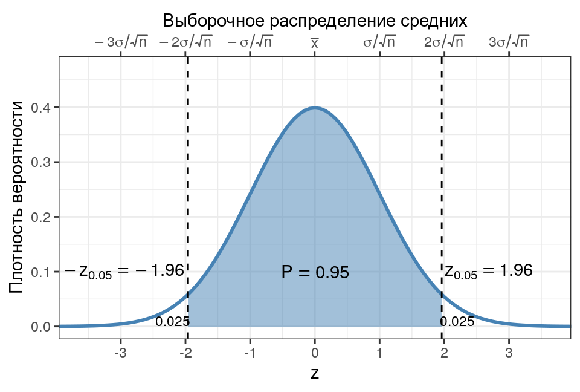

\[\bar {x} \pm z_{\alpha} \cdot \sigma / \sqrt{n}\]

Чтобы найти границы 95% доверительного интервала, нужно найти квантили стандартного нормального распределения, которые соответствуют вероятностям 0.025 и 0.975

```r
qnorm(p = c(0.025, 0.975))
```

```
## [1] -1.959964  1.959964
```

\(z_{0.05} = 1.96\)

95% выборочных средних в повторных выборках будут лежать в пределах \(\pm 1.96\) стандартных ошибок вокруг среднего значения.

## Условия применимости нормального распределения для доверительного интервала

1.Должна быть известна \(\sigma\) в генеральной совокупности.

2.Должны выполняться условия, при которых справедлива ЦПТ:

- Наблюдения в выборке должны быть независимы друг от друга.
- Большой объем выборки **или** нормальное распределение \(x\)

## Если \(\pmb \sigma\) не известна

Если \(\sigma\) в генеральной совокупности не известна, ее можно оценить по выборочному стандартному отклонению \(s\).

\[\sigma / \sqrt{n} \approx s/\sqrt{n}\]

После стандартизации:

\[\frac{\bar X - \mu}{SE_{\bar x}} = \frac{\bar X - \mu}{s / \sqrt{n}} \sim t_{df = n - 1}\]

стандартизованное распределение выборочных средних подчиняется \(t\)-распределению с числом степеней свободы \(df = n - 1\)

## \(t\)-распределение

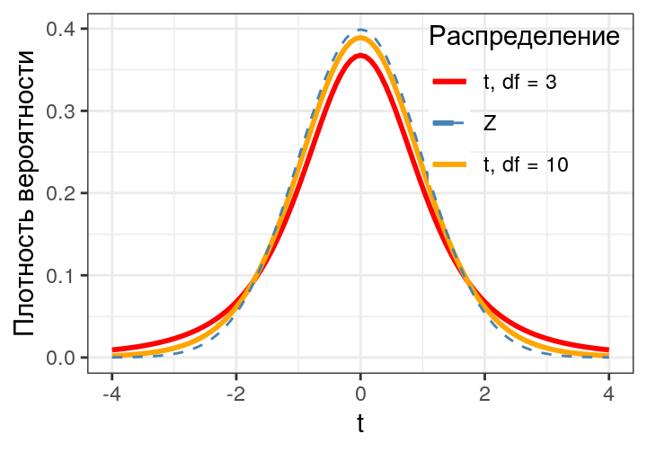

- Симметричное колоколообразное распределение с толстыми хвостами.
- Единственный параметр — число степеней свободы (для доверительного интервала \(df = n - 1\)).
- При увеличении объема выборки \(t\)-распределение приближается к нормальному.

## Доверительный интервал из \(t\)-распределения

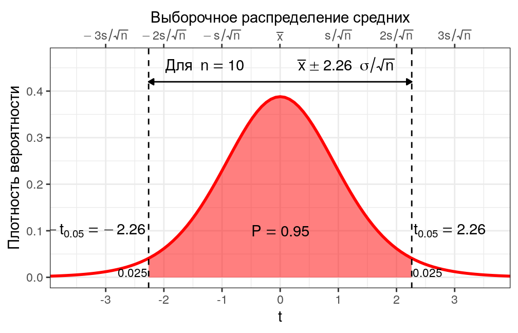

Обязательно используется, если:

- Объем выборки мал.
- \(\sigma\) не известна.

\[\bar {x} \pm t_{\alpha, df} \cdot s / \sqrt{n}\]

\(df = n - 1\)

Условия применимости

Выполняются условия, при которых справедлива ЦПТ:

- Наблюдения в выборке независимы друг от друга.
- Большой объем выборки и нет “выбросов” **или** нормальное распределение \(x\)

## Смысл 95% доверительного интервала.

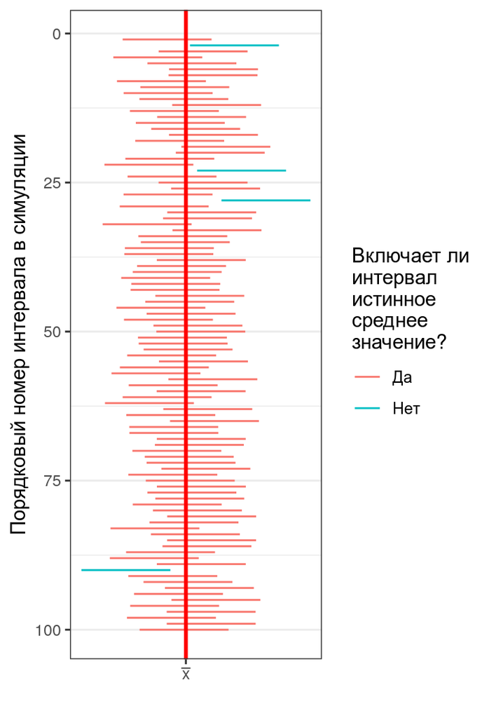

Среднее в генеральной совокупности — это фиксированная величина (она либо попала в интервал, либо нет.

Доверительный интервал — случайная величина.

В повторных выборках такого же размера \(\approx 95\%\) всех доверительных интервалов “накроют” истинное среднее значение.

## Расчет и изображение доверительного интервала в R

```r
library(ggplot2)
data("diamonds")

# цена бриллиантов хорошего качества огранки
good <- diamonds$price[diamonds$cut == "Good"]

.mean <- mean(good)                  # выборочное среднее
.n <- length(good)                   # объем выборки
SE <- sd(good)/ sqrt(.n)             # стандартная ошибка
t_crit <- qt(p = 0.975, df = .n - 1) # критич. зн. t для данного n и p = 0.95
err <- t_crit * SE                   # предел погрешности
# Границы доверительного интервала
.mean - err
```

```
## [1] 3825.819
```

```r
.mean + err
```

```
## [1] 4031.909
```

Можем записать среднюю цену бриллиантов хорошей огранки и ее доверительный интервал: \(3928.9 \pm 103\)

## Строим доверительные интервалы в ggplot

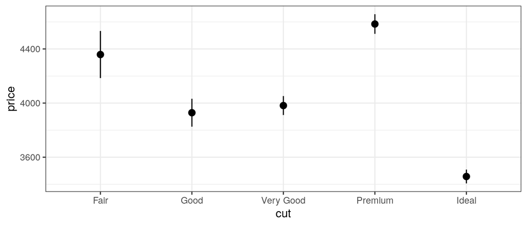

```r
theme_set(theme_bw())
ggplot(data = diamonds, aes(x = cut, y = price)) +
  stat_summary(geom = 'pointrange', fun.data = mean_cl_normal)
```

## Задание 1

Посчитайте среднюю цену и доверительный интервал для бриллиантов с такими свойствами:

- качество огранки (`cut`) идеальное (`Ideal`)
- прозрачность (`clarity`) наивысшая (`IF`)

Постройте график средней цены с доверительными интервалами для бриллиантов разного качества огранки и прозрачности.

## Решение

Вычислим границы доверительного интервала

```r
ideal <- diamonds$price[diamonds$cut == 'Ideal' & diamonds$clarity == 'IF']

.mean <- mean(ideal)                  # выборочное среднее
.n <- length(ideal)                   # объем выборки
SE <- sd(ideal)/ sqrt(.n)             # стандартная ошибка
t_crit <- qt(p = 0.975, df = .n - 1) # критич. зн. t для данного n и p = 0.95
err <- t_crit * SE                   # предел погрешности
# Границы доверительного интервала
.mean - err
```

```
## [1] 2085.768
```

```r
.mean + err
```

```
## [1] 2460.059
```

## Решение

Теперь можно построить график средней цены с доверительными интервалами для бриллиантов разного качества огранки и прозрачности. Для этого нужно к предыдущему графику добавить информацию о прозрачности.

Способ 1 (некрасивый, требует доработки):

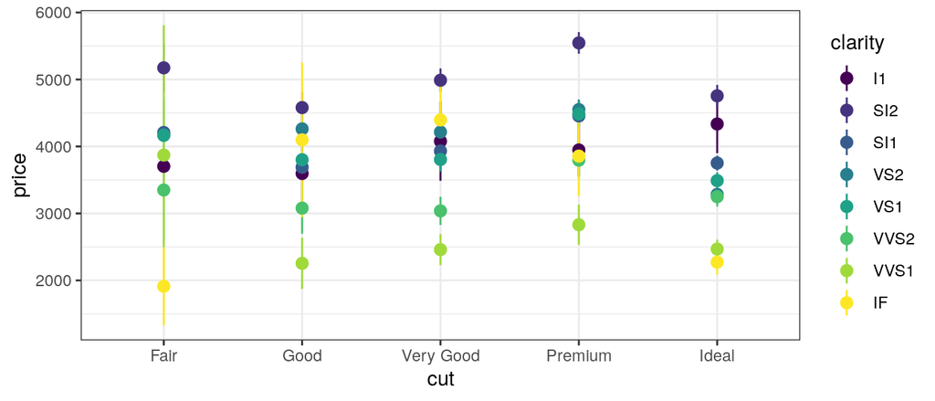

```r
ggplot(data = diamonds, aes(x = cut, y = price, colour = clarity)) +
  stat_summary(geom = 'pointrange', fun.data = mean_cl_normal)
```

## Решение

Способ 2 (удовлетворительный):

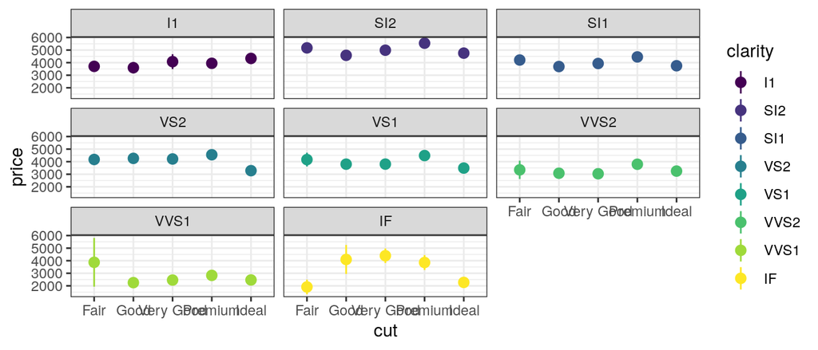

```r
ggplot(data = diamonds, aes(x = cut, y = price, colour = clarity)) +
  stat_summary(geom = 'pointrange', fun.data = mean_cl_normal) +
  facet_wrap(~ clarity)
```

Осторожно! Группы могут быть неоднородны. Здесь не учтен размер и т.п.

## Как устроено тестирование гипотез

## Сравнение выборок

Различия между выборками не всегда видны невооружённым глазом.

## Нулевая и альтернативная гипотезы

Это первый шаг

- Нулевая гипотеза \(H_0\) чаще всего формулируется как **отсутствие различий** между сравниваемыми объектами. Например: Улитки из обеих популяций одинакового размера
- Альтернативная гипотеза \(H_A\) формулируется как **присутствие различий**, она обратна нулевой гипотезе, т.е. включает все остальные случаи. Например: Улитки из обеих популяций разного размера.

## Нулевая и альтернативная гипотезы — это “два мира”

Вне зависимости от нас, реальность может находиться в одном из двух состояний:

- \(H_0\) верна, улитки одинаковы
- \(H_0\) неверна, улитки различаются

| \(H_0\) верна | \(H_0\) неверна |
| --- | --- |

После статистического теста мы принимаем решение о том, принять или отвергнуть \(H_0\). Но это решение не обязательно окажется верным. Возможно четыре исхода:

В мире где улитки одинаковы (\(H_0\) верна) мы можем:  
- принять \(H_0\) (верное решение),  
- отвергнуть \(H_0\) (ошибка).

Аналогично, в мире где улитки различаются (\(H_A\) верна), мы можем:  
- принять \(H_0\) (ошибка),  
- либо отвергнуть \(H_0\) (верное решение).

## Верные и неверные решения

**Ошибка I рода: нашли то, чего нет**

**Ошибка II рода: не нашли то, что было**

|  | \(H_0\) верна | \(H_0\) неверна |
| --- | --- | --- |
| Отклонить H0 | Ошибка I рода с вероятностью α Ложно-положительный результат | Верно |
| Сохранить H0 | Верно | Ошибка II рода с вероятностью β Ложно-отрицательный результат |

## Тестирование гипотез: Тестовые статистики

### 1. Формулируем нулевую и альтернативную гипотезы.

Гипотезы выражаются математически в виде тестовых статистик. На этом этапе мы делаем определенные допущения.

### 2. Проверяем **условия применимости** тестовой статистики.

### 3. По реальным данным вычисляем **эмпирическое значение тестовой статистики**.

Дальше мы должны ответить на вопрос:

**Насколько вероятно получить *такое или более экстремальное* эмпирическое значение, если верна нулевая гипотеза \(H_0\)?**

### 4. Строим теоретическое распределение тестовой статистики для случая, когда верна \(H_0\), и оцениваем по нему уровень значимости.

### 5. Решаем сохранить или отвергнуть \(H_0\).

Увы, мы не сможем узнать, какая гипотеза верна, но поймем, насколько с ней согласуются исходные данные.

## Одновыборочный \(t\)-тест

## Размер кладки черепах

Разберемся с одновыборочным \(t\)-тестом на вымышленном примере.

Представьте, что в одной статье сказано, что средняя плодовитость черепах определенного вида — 7 яиц в кладке.

В вашей выборке из \(33\) черепах — \(\bar x = 8.5\), \(s = 3.2\).

Отличается ли реальная плодовитость в обследованной вами популяции черепах от того, что указано в статье?

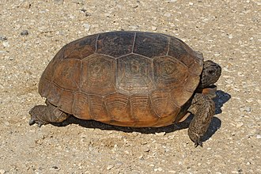

Gopher Tortoise by Judy Gallagher on Flickr

## Одновыборочный t-тест

- \(H_0: \mu = \mu_0\) — Реальная средняя плодовитость черепах такая, как в статье.
- \(H_A: \mu \ne \mu_0\) — Средняя плодовитость отличается от того, что написано в статье.

\(\mu_0\) — это какое-то конкретное значение. В нашей задаче это — 7 яиц в кладке.

\[t = \cfrac{\bar x - \mu}{ s / \sqrt{n} }\]

Если выполняется ЦПТ, то одновыборочная \(t\)-статистика подчиняется \(t\)-распределению  
с числом степеней свободы \(df = n - 1\).

Условия применимости:

- Наблюдения в выборке должны быть независимы друг от друга.
- Объем выборки достаточно велик **или** величины нормально распределены.

### Задание 2

Проверьте условия применимости t-теста. Вычислите t и p.

## Проверяем, нормально ли распределение

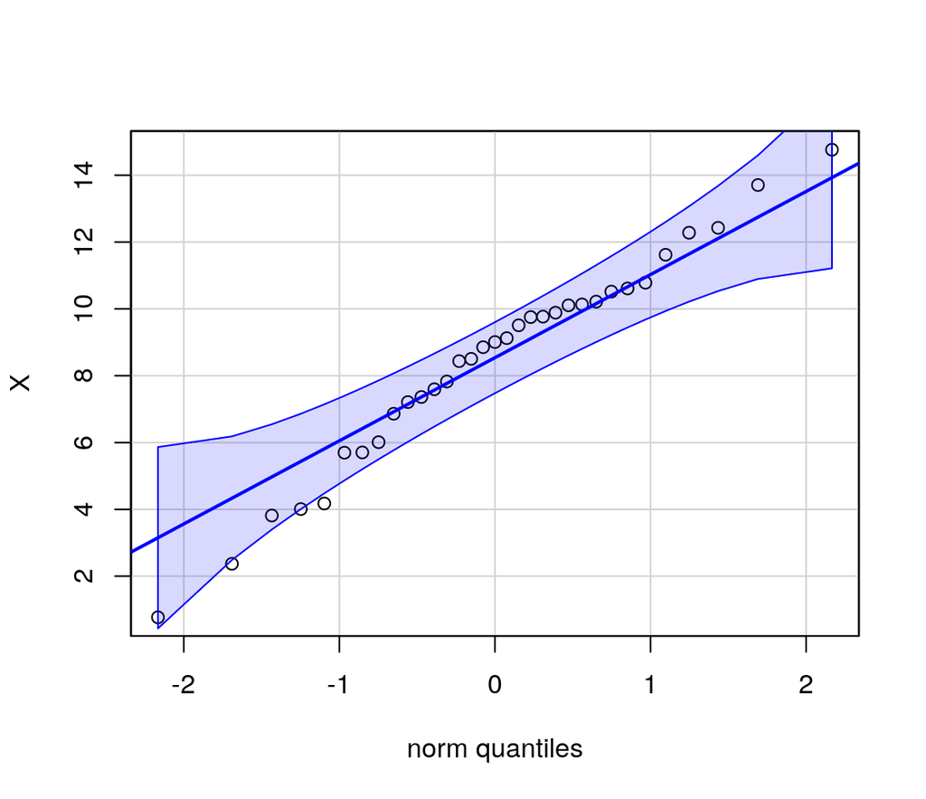

## Вычислим наблюдаемое значение \(t\)-статистики

\[t = \cfrac{\bar x - \mu}{ s / \sqrt{n} }\] Средняя плодовитость в выборке из 33 черепах \(\bar x = 8.5\), стандартное отклонение \(s = 3.2\). В статье указана плодовитость \(7\).

\[t = \cfrac{8.5 - 7}{ 3.2 / \sqrt{33} } = 2.7\]

## Насколько это значение согласуется с \(H_0\)?

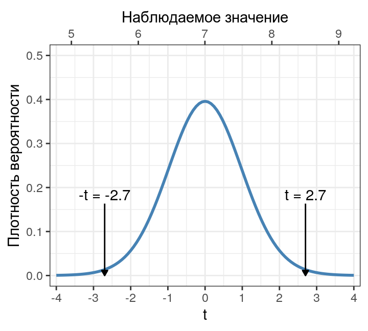

При \(H_0\) значение \(t\) будет близко к нулю.

Насколько необычны значения t меньше или больше \(\pm 2.7\)?

## Уровень значимости (\(p\)-value)

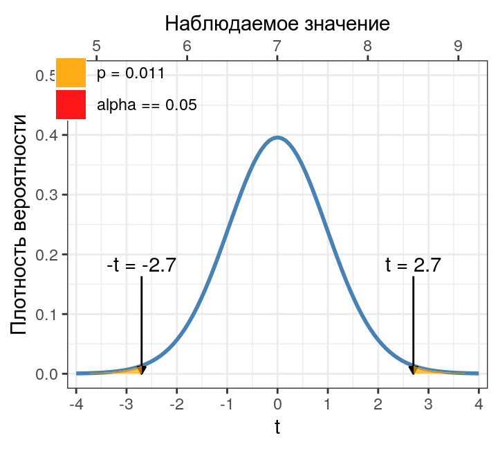

**Уровень значимости** — это вероятность получить значение \(t\) меньше или больше данного, если бы \(H_0\) была справедлива.

## Уровень значимости (\(p\)-value)

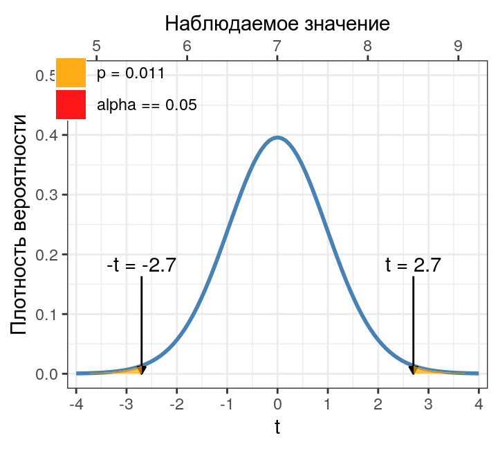

Можно вычислить значение \(p\)

```r
2 * ( 1 - pt(2.7, df = 33 - 1) )
```

```
## [1] 0.01098686
```

Если бы плодовитость не отличалось от указанной в статье, получить \(t\) меньше или больше \(2.7\) можно было бы с вероятностью \(p = 0.011\).

## Критический уровень значимости

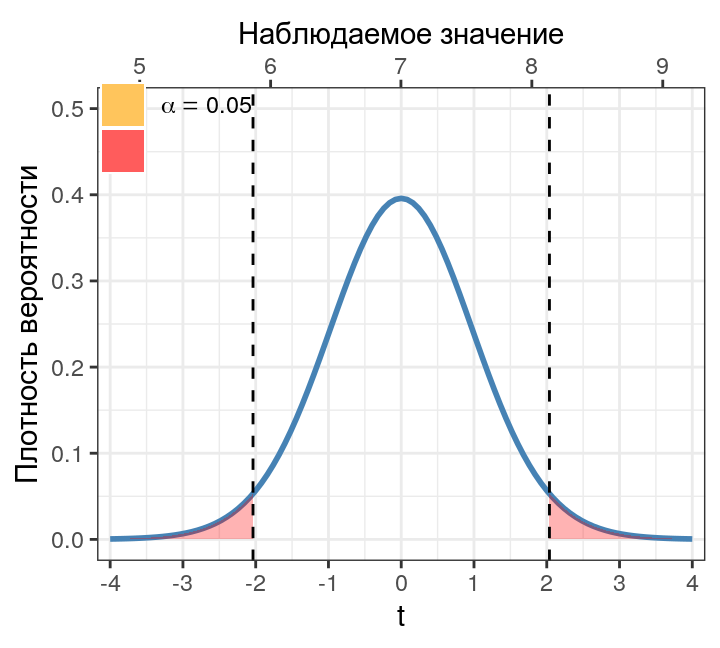

Критический уровень значимости \(\alpha\) — это порог для принятия решений.

Обычно используют \(\alpha = 0.05\).

Если \(p \le \alpha\) — отвергаем \(H_0\) и принимаем \(H_A\).

Если \(p > \alpha\) — сохраняем \(H_0\), не можем ее отвергнуть.

## Принимаем решение

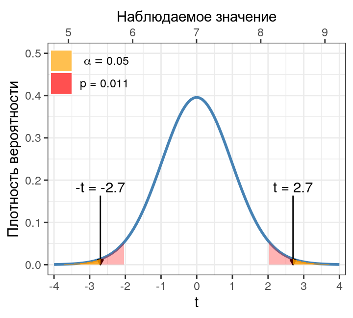

Мы получили \(p < \alpha\), поэтому отвергаем \(H_0\) и принимаем \(H_A\).

Фактическая плодовитость статистически значимо отличается от указанной в статье.

## Заблуждения о \(p\)-values

- Правда ли, что \(p\) — вероятность того, что верна сама \(H_0\)?
- Нет! Значение \(p\) всегда считается **при условии, что \(H_0\) верна**. Но \(H_0\) может быть неверна.
- Правда ли, что \(p\) — это вероятность получить такое значение статистики при справедливой \(H_0\)?
- Нет! Вероятность вычисляется как площадь под участком кривой. Конкретное значение статистики — это точка и под ней нет площади.
- Правда ли, что если \(p > 0.05\), то различий между группами на самом деле нет?
- Нет! Это значит, что наблюдаемый эффект согласуется с нулевой гипотезой. Различия могут быть.

## Статистические ошибки при проверке гипотез

## Статистические ошибки при проверке гипотез

**Ошибка I рода: нашли то, чего нет**

**Ошибка II рода: не нашли то, что было**

|  | \(H_0\) верна | \(H_0\) неверна |
| --- | --- | --- |
| Отклонить H0 | Ошибка I рода с вероятностью α Ложно-положительный результат | Верно |
| Сохранить H0 | Верно | Ошибка II рода с вероятностью β Ложно-отрицательный результат |

Как эти ошибки выглядят на графике? Как они взаимосвязаны?

## Можно построить распределения при \(H_0\) и \(H_A\)

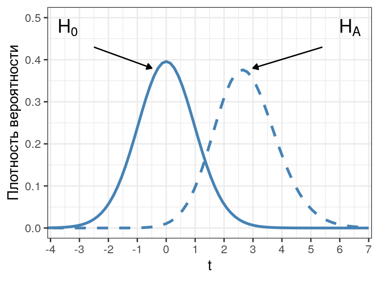

Распределение статистики, когда справедлива \(H_0\), нам уже знакомо — его мы используем в тестах.

Но может быть справедлива \(H_A\) и ее тоже можно описать своим распределением.

При помощи этих распределений можно определить вероятность ошибок различных типов.

## Ошибка I рода — найти различия там, где их нет

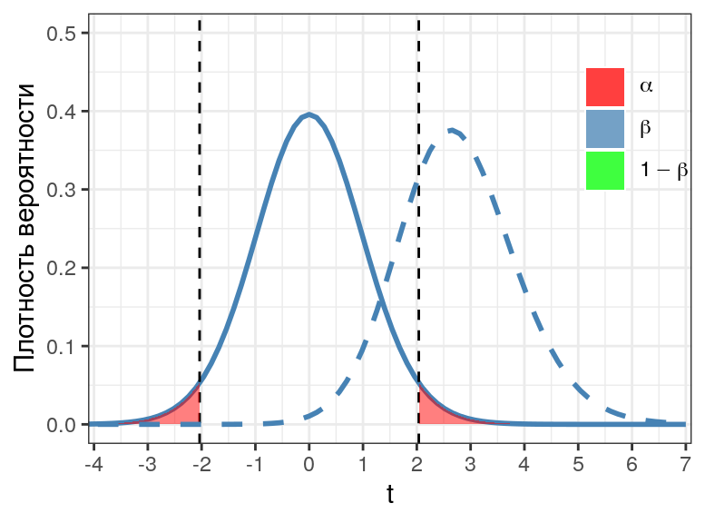

\(\alpha\) (критический уровень значимости) — это вероятность ошибки I рода.

Если \(H_0\) справедлива, то при \(\alpha = 0.05\) мы отвергаем ее с 5% вероятностью.

Чтобы снизить вероятность таких ошибок, можно уменьшить \(\alpha\).

## Ошибка II рода — не найти различий, где они есть

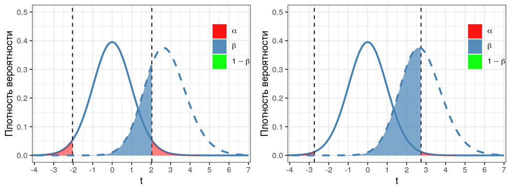

\(\beta\) — вероятность ошибки II рода.

Считается, что допустимо \(\beta \le 0.2\), но часто про нее забывают.

Если мы уменьшаем \(\alpha\) (график справа), то возрастает \(\beta\).

## Мощность теста — вероятность найти различия, если они есть

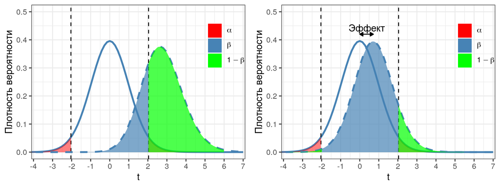

\(Power = 1 - \beta\) — мощность теста.

Хорошо, когда мощность не меньше \(0.8\).

Мощность теста зависит от величины наблюдаемого эффекта (от величины различий).

## С увеличением объема выборки растет мощность теста

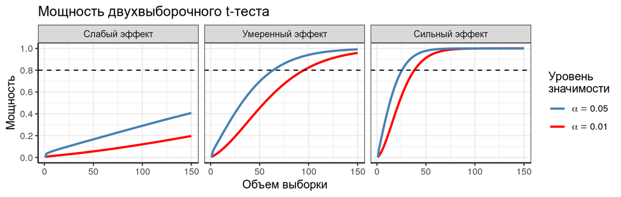

## Двухвыборочный t-тест

## Гипотезы в двухвыборочном \(t\)-тесте и тестовая статистика

\(H_0: \mu_1 - \mu_2 = 0\) — средние значения не различаются в двух группах

\(H_A: \mu_1 - \mu_2 \ne 0\) — средние значения различаются

Т.е. нас интересует **разность выборочных средних**.

Ее ожидаемое значение при \(H_0\) будет 0.

t-тест в общем виде выглядит так

\[t=\frac{\text{Наблюдаемая величина - Ожидаемое значение}}{\text{Стандартная ошибка}}\]

## t-тест и его разновидности

Двухвыборочный t-тест используется для проверки значимости различий между средними

\[t=\frac{(\bar{x}_1 - \bar{x}_2) - (\mu_1 - \mu_2)}{SE_{\bar{x}_1 - \bar{x}_2}} \; = \; \frac{\bar{x}_1 - \bar{x}_2}{SE_{\bar{x}_1 - \bar{x}_2}}\]

\(SE_{\bar{x}_1 - \bar{x}_2}\) — стандартная ошибка разности двух средних, может рассчитываться по-разному

- t-тест Стьюдента — если считать, что дисперсии в группах равны
- t-тест Уэлча — если считать, что дисперсии могут быть разными

## Стандартная ошибка разности средних в t-тесте Стьюдента

Если группы независимы и дисперсии в них равны, то по центральной предельной теореме

\[SE_{\bar{x}_1 - \bar{x}_2} = \sqrt{ \frac{\sigma^2}{n_{1}} + \frac{\sigma^2}{n_{2}}} \approx \sqrt{ \frac{s^2}{n_{1}} + \frac{s^2}{n_{2}}}\]

\(s^2 = \cfrac{(n_1 - 1)s^2_1 + (n_2 - 1)s^2_2}{n_1 + n_2 - 2}\) — это **обобщенная дисперсия** по двум выборкам.

Результирующая \(t\)-статистика подчиняется \(t\)-распределению с \(df = n_1 + n_2 - 2\).

Осторожно, равенство дисперсий в группах —  
это часто нереалистичное предположение!

## Cтандартная ошибка разности средних в t-тесте Уэлча

Если группы независимы и дисперсии в них неизвестны, то получается

\[SE_{\bar{x}_1 - \bar{x}_2} = \sqrt{ \frac{\sigma^2_{1}}{n_{1}} + \frac{\sigma^2_{2}}{n_{2}}} \approx \sqrt{ \frac{s^2_{1}}{n_{1}} + \frac{s^2_{2}}{n_{2}}}\]

Проблема в том, что эта величина **лишь приблизительно следует t-распределению**, если считать его степени свободы как обычно для двух групп \(df = n_1 + n_2 - 2\).

Это из-за того, что мы оцениваем **две** дисперсии  
при помощи их стандартных отклонений.

## Приблизительное число степеней свободы

Можно рассчитать по уравнению Уэлча-Саттеруэйта. Это решит проблему.

\[df_{ Welch-Satterthwaite} \approx \cfrac {\bigg(\cfrac{s^2_{1}}{n_{1}} + \cfrac{s^2_{2}}{n_{2}}\bigg)^2} {\cfrac{1}{n_{1} - 1}\bigg(\cfrac {s_{1}^2} {n_{1}}\bigg)^2 + \cfrac{1}{n_{2} - 1}\bigg(\cfrac {s_{2}^2} {n_{2}}\bigg)^2}\]

t-тестом Уэлча можно пользоваться, даже если дисперсии равны.

Он немного консервативнее, чем тест Стьюдента.

## Условия применимости двухвыборочного t-теста

Почти такие же, как условия справедливости ЦПТ

- Наблюдения независимы друг от друга.
- Выборки независимы друг от друга (новое условие).
- Объем выборки достаточно велик или величины нормально распределены.

## Двухвыборочный t-тест в R

## Пример: Гормоны и артериальная гипертензия

Синдром Кушинга — это нарушения уровня артериального давления, вызванные гиперсекрецией кортизола надпочечниками.

В датасете `Cushings` (пакет `MASS`) записаны данные о секреции двух метаболитов при разных типах синдрома (данные из кн. Aitchison, Dunsmore, 1975).

- `Tetrahydrocortisone` — секреция тетрагидрокортизона с мочой (мг/сут.)
- `Pregnanetriol` — секреция прегнантриола с мочой (мг/сут.)
- `Type` — тип синдрома:
  - `a` — аденома
  - `b` — двусторонняя гиперплазия
  - `c` — карцинома
  - `u` — не известно

Давайте сравним секрецию тетрагидрокортизона при аденома и двусторонней гиперплазии надпочечников. Различается ли она?

## Открываем данные

```r
library(MASS)
data("Cushings")
```

Все ли правильно открылось?

```r
head(Cushings)
```

```
##    Tetrahydrocortisone Pregnanetriol Type
## a1                 3.1         11.70    a
## a2                 3.0          1.30    a
## a3                 1.9          0.10    a
## a4                 3.8          0.04    a
## a5                 4.1          1.10    a
## a6                 1.9          0.40    a
```

```r
str(Cushings)
```

```
## 'data.frame':    27 obs. of  3 variables:
##  $ Tetrahydrocortisone: num  3.1 3 1.9 3.8 4.1 1.9 8.3 3.8 3.9 7.8 ...
##  $ Pregnanetriol      : num  11.7 1.3 0.1 0.04 1.1 0.4 1 0.2 0.6 1.2 ...
##  $ Type               : Factor w/ 4 levels "a","b","c","u": 1 1 1 1 1 1 2 2 2 2 ...
```

## Знакомимся с данными

Есть ли пропущенные значения?

```r
colSums(is.na(Cushings))
```

```
## Tetrahydrocortisone       Pregnanetriol                Type
##                   0                   0                   0
```

Каковы объемы выборки в каждой группе?

```r
table(Cushings$Type)
```

```
##
##  a  b  c  u
##  6 10  5  6
```

Обратите внимание, объемы выборок **маленькие**.

## Проверяем условия применимости…

1.Наблюдения независимы друг от друга?

- Да, независимы. Это случайная выборка.

2.Выборки независимы друг от друга?

- Да, независимы. В группах разные люди (естественно, т.к. тип синдрома у человека может быть только какой-то один).

3.Объем выборки достаточно велик или величины нормально распределены?

- Объем выборки мал

```r
table(Cushings$Type)
```

```
##
##  a  b  c  u
##  6 10  5  6
```

Нужно проверить форму распределения в обеих группах.

## Нормально ли распределены концентрации тетрагидрокортизона в группах?

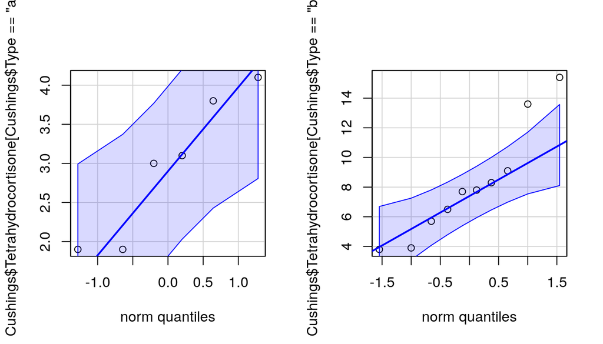

```r
library(car)
qqPlot(Cushings$Tetrahydrocortisone[Cushings$Type == 'a'])
qqPlot(Cushings$Tetrahydrocortisone[Cushings$Type == 'b'])
```

Удовлетворительно. При таких малых объемах выборки сложно ожидать лучшего.

## Двухвыборочный t-тест в R: способ 1.

Сравним секрецию тетрагидрокортизона при помощи **двухвыборочного** t-теста.

```
t.test(x = значения_в_гр.1,
       y = значения_в_гр.2)
```

```r
tt <- t.test(x = Cushings$Tetrahydrocortisone[Cushings$Type == 'a'],
             y = Cushings$Tetrahydrocortisone[Cushings$Type == 'b'])
tt
```

```
##
##  Welch Two Sample t-test
##
## data:  Cushings$Tetrahydrocortisone[Cushings$Type == "a"] and Cushings$Tetrahydrocortisone[Cushings$Type == "b"]
## t = -4.1499, df = 10.685, p-value = 0.001719
## alternative hypothesis: true difference in means is not equal to 0
## 95 percent confidence interval:
##  -7.988307 -2.438360
## sample estimates:
## mean of x mean of y
##  2.966667  8.180000
```

## Опишем результаты

```
##
##  Welch Two Sample t-test
##
## data:  Cushings$Tetrahydrocortisone[Cushings$Type == "a"] and Cushings$Tetrahydrocortisone[Cushings$Type == "b"]
## t = -4.1499, df = 10.685, p-value = 0.001719
## alternative hypothesis: true difference in means is not equal to 0
## 95 percent confidence interval:
##  -7.988307 -2.438360
## sample estimates:
## mean of x mean of y
##  2.966667  8.180000
```

- Секреция тетрагидрокортизона значимо различается у пациентов с аденомой и двусторонней гиперплазией надпочечников (\(t_{10.69} = -4.15\), \(p = < 0.05\))

Можно указать в скобках не сравнение с \(\alpha\), а само значение \(p\):  
(\(t_{10.69} = -4.15\), \(p = 0.0017\)).

Только не надо безумствовать и указывать слишком много знаков…

## Задание 3: Двухвыборочный t-тест в R, способ 2.

Перепишите вызов функции t.test с использованием другого шаблона вызова (с использованием формулы).

`t.test(formula = что_зависит ~ группы, data = данные)`

Второй вариант синтаксиса можно использовать только, если у вас есть только две группы. Если групп больше, то можно отфильтровать нужные с помощью логического вектора.

```
t.test(formula = что_зависит ~ группы, data = данные,
       subset = логический_вектор)
```

## Решение: Двухвыборочный t-тест в R, способ 2.

`t.test(formula = что_зависит ~ группы, data = данные)`

Второй вариант синтаксиса можно использовать только, если у вас есть только две группы. Если групп больше, то можно отфильтровать нужные с помощью логического вектора.

```
t.test(formula = что_зависит ~ группы, data = данные,
       subset = логический_вектор)
```

```r
t.test(formula = Tetrahydrocortisone ~ Type, data = Cushings,
       subset = Cushings$Type %in% c('a', 'b'))
```

[output not shown]

Результаты точно такие же, естественно.

## Задание 4

Посмотрите структуру результатов (`tt`) при помощи функции `str()` и извлеките из них:

- степени свободы
- уровень значимости
- значение t-критерия

## Решение: Что спрятано в результатах?

Как называются отдельные элементы результатов можно узнать посмотрев их структуру при помощи функции `str()`

```r
str(tt)
```

```
## List of 10
##  $ statistic  : Named num -4.15
##   ..- attr(*, "names")= chr "t"
##  $ parameter  : Named num 10.7
##   ..- attr(*, "names")= chr "df"
##  $ p.value    : num 0.00172
##  $ conf.int   : num [1:2] -7.99 -2.44
##   ..- attr(*, "conf.level")= num 0.95
##  $ estimate   : Named num [1:2] 2.97 8.18
##   ..- attr(*, "names")= chr [1:2] "mean of x" "mean of y"
##  $ null.value : Named num 0
##   ..- attr(*, "names")= chr "difference in means"
##  $ stderr     : num 1.26
##  $ alternative: chr "two.sided"
##  $ method     : chr "Welch Two Sample t-test"
##  $ data.name  : chr "Cushings$Tetrahydrocortisone[Cushings$Type == \"a\"] and Cushings$Tetrahydrocortisone[Cushings$Type == \"b\"]"
##  - attr(*, "class")= chr "htest"
```

## Решение: Можно получить элементы результатов в виде отдельных чисел

```r
tt$parameter # степени свободы
```

```
##       df
## 10.68512
```

```r
tt$p.value # уровень значимости
```

```
## [1] 0.00171934
```

```r
tt$statistic # значение t-критерия
```

```
##         t
## -4.149899
```

## График со средними и доверительными интервалами

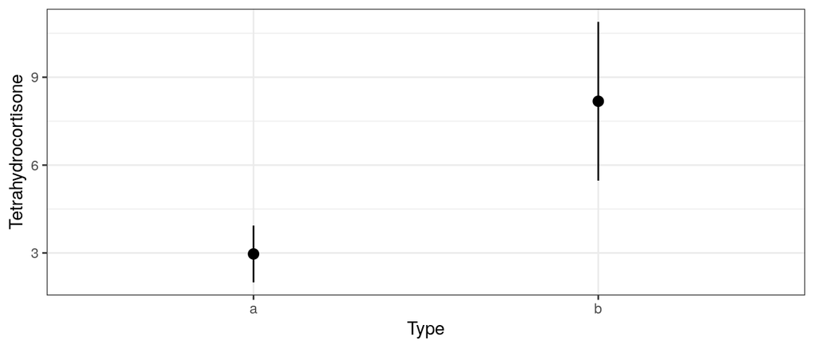

```r
ggplot(data = Cushings[Cushings$Type %in% c('a', 'b'), ],
       aes(x = Type, y = Tetrahydrocortisone)) +
  stat_summary(fun.data = mean_cl_normal)
```

## Двухвыборочный t-тест (самостоятельная работа)

## Задание 5

Файл `aml.csv` содержит данные о влиянии регулярной химиотерапии на продолжительность ремиссии.

Прочитаем эти данные

```r
rem <- read.csv(file = "data/aml.csv", header = TRUE)
head(rem)
```

```
##   time group
## 1    9     1
## 2   13     1
## 3   13     1
## 4   18     1
## 5   23     1
## 6   28     1
```

- В переменной `time` представлена продолжительность ремиссии в днях.
- `group` указывает, к какой экспериментальной группе принадлежал пациент. В группе 1 проводилась регулярная химиотерапия, в группе 2 - нет.

Ваша задача сравнить эти группы с помощью t-теста.

## Решение: Разведочный анализ

```r
str(rem)
```

```
## 'data.frame':    23 obs. of  2 variables:
##  $ time : int  9 13 13 18 23 28 31 34 45 48 ...
##  $ group: int  1 1 1 1 1 1 1 1 1 1 ...
```

```r
# Делаем group фактором
rem$group <- factor(rem$group, labels = c("therapy", "control"))

# Пропущенные значения?
colSums(is.na(rem))
```

```
##  time group
##     0     0
```

```r
# Объемы выборок?
table(rem$group)
```

```
##
## therapy control
##      11      12
```

## Решение: Проверка условий применимости

```r
# Выборки малы, поэтому проверяем на нормальность и отсутствие выбросов
op <- par(mfrow = c(1, 2))
qqPlot(rem$time[rem$group == "therapy"])
```

```
## [1] 11  1
```

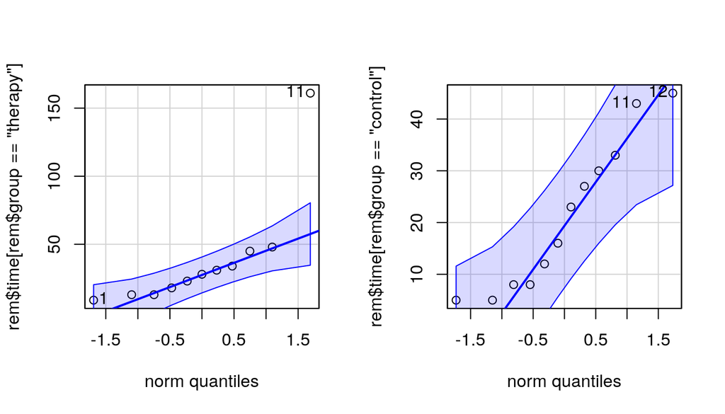

```
## [1] 12 11
```

```r
qqPlot(rem$time[rem$group == "control"])
```

```r
par(op)
```

## Решение: Проверка условий применимости

Есть отскакивающее значение в группе `therapy`, в этой группе оно 11 по порядку (видно на `qqPlot()`).

```r
rem$time[rem$group == "therapy"]
```

```
##  [1]   9  13  13  18  23  28  31  34  45  48 161
```

```r
rem$time[rem$group == "therapy"][11]
```

```
## [1] 161
```

Пусть в этом случае это вполне реальное наблюдение, но это значение придется исключить, т.к. t-тест не устойчив к выбросам.

## Решение: Двухвыборочный t-тест

```r
# удалено наблюдение со значением 161
tt <- t.test(formula = time ~ group, data = rem,
       subset = rem$time != 161)
```

Или то же самое:

```r
# удалено 11 наблюдение в группе `therapy`
tt <- t.test(x = rem$time[rem$group == 'therapy'][-11],
       y = rem$time[rem$group == 'control'])
```

## Решение: Результаты двухвыборочного t-теста

```r
tt
```

```
##
##  Welch Two Sample t-test
##
## data:  rem$time[rem$group == "therapy"][-11] and rem$time[rem$group == "control"]
## t = 0.83114, df = 19.685, p-value = 0.4159
## alternative hypothesis: true difference in means is not equal to 0
## 95 percent confidence interval:
##  -7.486117 17.386117
## sample estimates:
## mean of x mean of y
##     26.20     21.25
```

## Решение: График со средними и доверительными интервалами

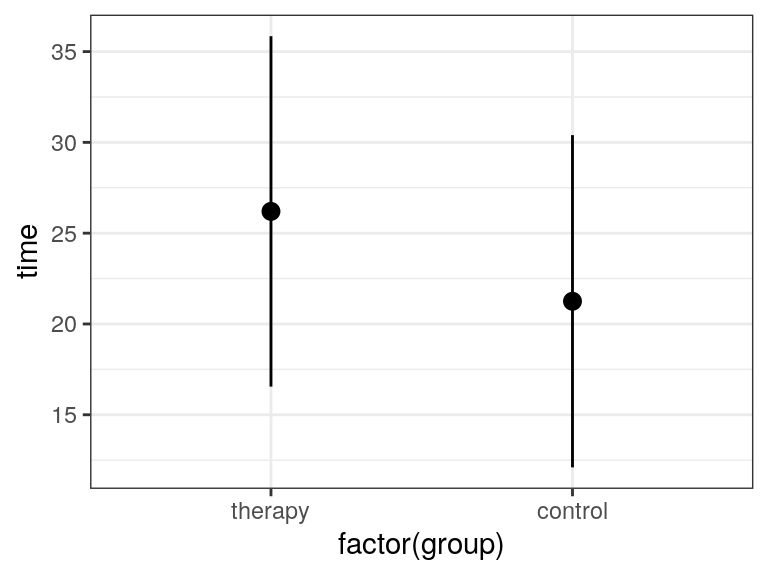

```r
ggplot(data = rem[rem$time != 161, ], aes(x = factor(group), y = time)) +
  stat_summary(fun.data = mean_cl_normal)
```

## Парный t-тест (факультативно)

## Пример: Снотворное

В датасете `sleep` содержатся данные об увеличении продолжительности сна по сравнению с контролем после применения двух снотворных препаратов (Cushny, Peebles, 1905, Student, 1908)

Одинаково ли два снотворных влияют на увеличение продолжительности сна?

```r
data(sleep)
head(sleep)
```

```
##   extra group ID
## 1   0.7     1  1
## 2  -1.6     1  2
## 3  -0.2     1  3
## 4  -1.2     1  4
## 5  -0.1     1  5
## 6   3.4     1  6
```

```r
# str(sleep)
```

## Проверяем условия применимости…

1.Наблюдения независимы друг от друга?

- Да, независимы. Это случайная выборка людей.

2.Выборки независимы друг от друга?

- **Нет!**. В группах одни и те же люди (10 человек, каждый пил оба снотворных).  
  **ОСТОРОЖНО**. Эти данные НЕ ПОДХОДЯТ для двухвыборочного t-теста, т.к. группы не являются взаимно независимыми. Нужно использовать **парный** t-тест.

3.Объем выборки достаточно велик или величины нормально распределены?

- Объем выборки мал

```r
table(sleep$group)
```

```
##
##  1  2
## 10 10
```

Нужно проверить форму распределения в обеих группах.

## Нормально ли распределена зависимая переменная в группах?

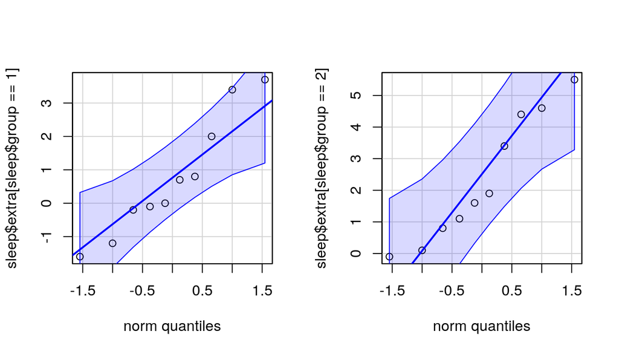

```r
qqPlot(sleep$extra[sleep$group == 1])
qqPlot(sleep$extra[sleep$group == 2])
```

Хорошо. Можно аппроксимировать нормальным распределением

## Парный t-тест в R

Сравним увеличение продолжительности сна при помощи **парного** t-теста.

```r
t.test(formula = extra ~ group, data = sleep, paired = TRUE)
```

```
##
##  Paired t-test
##
## data:  extra by group
## t = -4.0621, df = 9, p-value = 0.002833
## alternative hypothesis: true difference in means is not equal to 0
## 95 percent confidence interval:
##  -2.4598858 -0.7001142
## sample estimates:
## mean of the differences
##                   -1.58
```

## Опишем результаты

```
##
##  Paired t-test
##
## data:  extra by group
## t = -4.0621, df = 9, p-value = 0.002833
## alternative hypothesis: true difference in means is not equal to 0
## 95 percent confidence interval:
##  -2.4598858 -0.7001142
## sample estimates:
## mean of the differences
##                   -1.58
```

- Различия изменения продолжительности сна при применении двух препаратов были достоверны (\(t_{9} = -4.06\), \(p = < 0.01\))

**Кстати, если бы мы не учли зависимость между группами, мы пришли бы к неверному выводу.** В этом можно убедиться, выполнив этот код:

```r
t.test(formula = extra ~ group, data = sleep)
```

## График со средними и доверительными интервалами

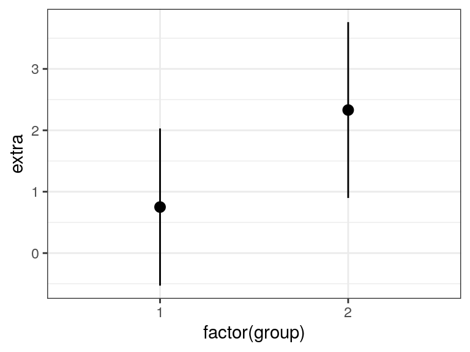

```r
ggplot(data = sleep, aes(x = factor(group), y = extra)) +
  stat_summary(fun.data = mean_cl_normal)
```

## Take-home messages

- По центральной предельной теореме выборочные средние нормально распределены \[\bar X \sim N (\mu, \sigma / \sqrt{n})\].
- Доверительный интервал к среднему значению можно построить из нормального распределения, если известна \(\sigma\) в генеральной совокупности, или из \(t\)-распределения, если она не известна.
- При тестировании нулевой гипотезы оценивают вероятность получения данного или более экстремального значения тестовой статистики при условии, что \(H_0\) справедлива. Если эта вероятность меньше выбранного критического уровня значимости, то нулевую гипотезу отвергают.
- Для сравнения выборочных средних лучше использовать t-критерий в модификации Уэлча, который учитывает, что дисперсии в группах могут быть разными.
- Средние в независимых выборках нужно сравнивать двухвыборочным t-тестом.
- Если выборки зависимы — нужно это учесть, поэтому для сравнения средних используется парный t-тест.

## Дополнительные ресурсы

- OpenIntro: Statistics
- Quinn, Keough, 2002
- Sokal, Rohlf, 1995
- Zar, 1999